# Investigating Tests for Equality of Variances

Andrew Nguyen

06/04/2021

## Introduction

Before performing an ANOVA test, the assumption of equal variances within each group must be satisfied. We are already familiar with the F-test, which takes the ratio of two variances as its test statistic. However, this method only works well if the population distributions it is testing are each approximately normally distributed. Fortunately, there are numerous other tests for variance equality to use for non-Normal situations. The hupotheses for the tests of equal variance are as follows:

$$H_o: \sigma^2_1 = \sigma^2_2 \\ H_a: \sigma^2_1 \neq \sigma^2_2$$

## Simulation: Normal distributions

Let us say there is a fish cooking competition, and we want to determine if there is a significant difference between the mean scores of Chef A’s cooked fish and Chef B’s cooked fish. The fish can be divided up to *n* portions, one for each judge. Before performing the hypothesis test, we need know if the variance in scores for Chef’s A fish is about equal to that for Chef B’s fish. The scores of the observant judges roughly follow a Normal distribution. The metric we will be using to analyze sensitivity is the proportion of hypothesis tests that are rejected under a significance level of .05. Below is a function takes in a sample size for both groups, a mean equal for each group for the sake of consistency, two standard deviations, and the number of reps or hypothesis tests to run. In other words, we can assume that the mean scores for each chef are equal. We want to focus more on the variances of their scores.

```r
norm_function <- function(n, mean, sd1, sd2, reps) {
  ft.pvalues = vector(length = reps)
  b.pvalues <- vector(length = reps)
  lev.pvalues <- vector(length = reps)
  bf.pvalues <- vector(length = reps)
  for (i in 1:reps) {
    flavor1 <- rnorm(n, mean = mean, sd = sd1)
    flavor2 <- rnorm(n, mean = mean, sd = sd2)
    flavor <- c(flavor1,flavor2)
    method <- c(rep(1,n),rep(2,n))
    df = data.frame(cbind(method, flavor))
    ft <- var.test(flavor1,flavor2)
    bt <- bartlett.test(flavor~factor(method),df)
    lev <- leveneTest(flavor~factor(method),center="mean",df)

    ft.pvalues[i] = ft$p.value
    b.pvalues[i] = bt$p.value
    lev.pvalues[i] = lev$`Pr(>F)`[1]
  }
  return(list(ftest=ft.pvalues,bartlett=b.pvalues,levene=lev.pvalues))
}
```

Below we save the p-values of 500 hypothesis tests for each test of equality. In this simulation, we investigate the results when both variances of Normal population distributions are equal, that is, the null hypothesis for each test is true. We can create histograms of the p-values as well. The sample size is 100. As we can see, they are roughly uniformly distributed, as expected from a situation where the null hypotheses are true. The F-test and Barlett test rejected 6.2% of the tests, while the Levene test rejected 5.8%.

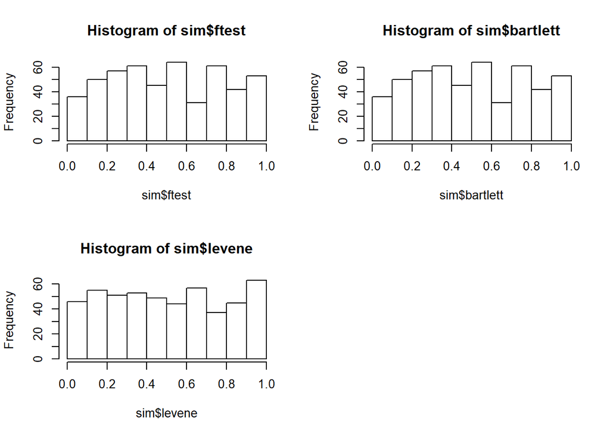

The histograms below the results from when the two variances are equal to 1 and 1.44.

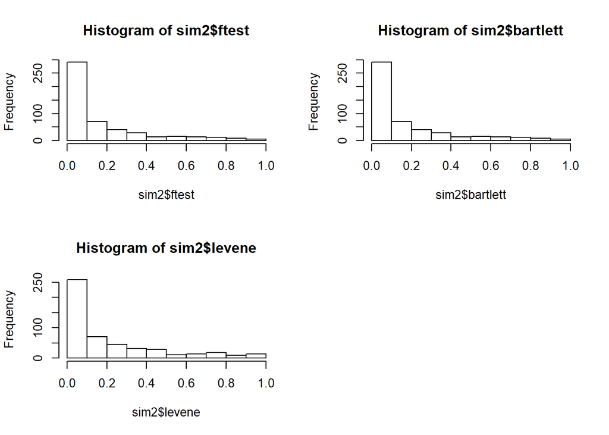

From the histograms, 41.6% of the tests are rejected by the F-test and Bartlett test individually, and 34.6% rejected by Levenne’s test. The F-test and Bartlett’s test both give the exact same proportion of tests that were rejected. Upon further inspection, they both give nearly equal p-values to each other, differing by several decimal places. From here on out, we will just keep the F-test in our analyses to avoid redundancy; the only different between the two methods is that Bartlett’s test can test for more than two variances.

## Simulation: Exponential distribution

Now we look at the case where the population distributions are exponential. Since the mean and variance are proportional to each other, we just have to enter the desired averages to perform the tests. The function to simulate this is very similar to above, except we are now sampling from our specified exponential distributions. The line plots below compare and contrast the proportion of tests rejected for different scenarios. The top two plots occur when sampled from Normal distributions for comparison. The bottom two plots occur under exponentially distributed populations.

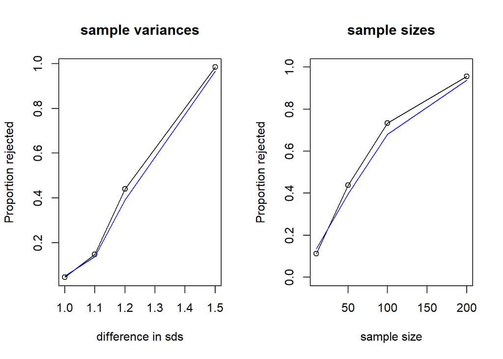

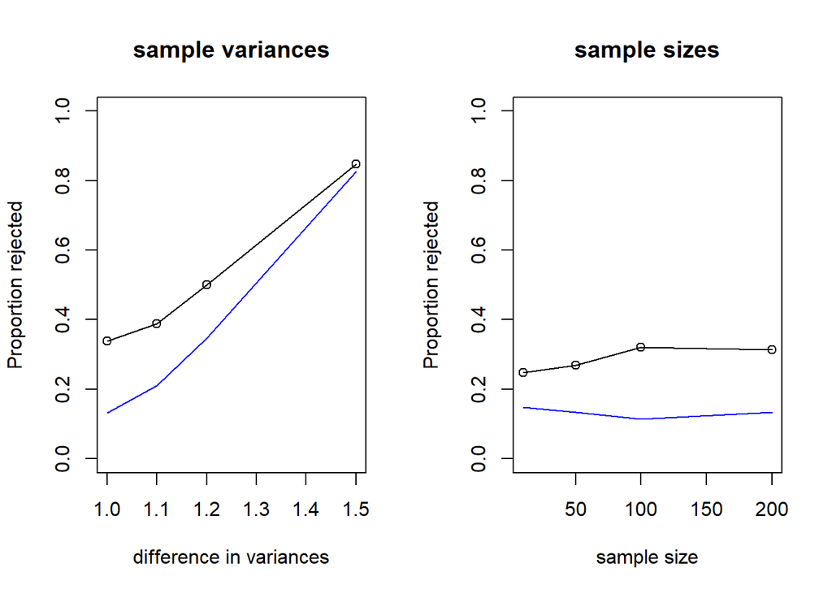

## Brown-Forsythe test

Despite its leniency, Levene’s test still wrongly rejects a decent proportion of tests, however. The test involves calculating the absolute difference between an observation and its respective group mean, incorporated as the dependent variable into its test statistic that would result from a one-way ANOVA.

$$W = \frac{N-k}{k-1} \frac{\sum^k_{i=1} {N_i(\bar{Z_i}-\bar{Z_{..}})^2}}{\sum^k_{i=1} {\sum_{j=1}^{N_i}(Z_{ij}-\bar{Z_{i.}})^2}} \\ \text{ where }Z_{ij} = |Y_{ij}-\bar{Y}_{i.}|$$

We can modify the test statistic to get another named test; by finding the absolute difference between observations and group medians instead, we are performing the Brown-Forsythe test of variance. Y-bar i-dot in the above formula would be replaced with the respective group median. This is known to be a more robust way to test variance equalities under non-Normal situations.

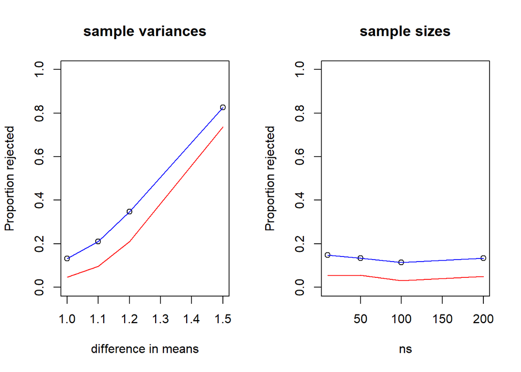

The blue plot represents Levene’s test, while the red plot represents Brown-Forsythe’s. The two plots depict situations when the two population distributions are exponential with equal means, thus equal variances. The B-F test consistently rejects lower proportions of tests incorrectly as the difference in means, in turn variances between the two samples increase at size of 100. Both incorrect rejection rates remain constant as sample size increases and means remaining equal and constant, but B-F test rates always remain lower. We can clearly tell that switching to medians as the center for the test statistic proves to be a more robust method for testing variance equality, as it remains more lenient towards the normality assumption than Levene does.

## Setbacks/limits and Conclusion

If more time and/or computing power was given for the project, it would be possible to run more than 500 hypothesis tests at a time like we are doing now to have the proportions of rejected tests converge more. We could also look into more equality of variances tests out there besides the ones we looked at. Additionally, we could examine more parameters besides the difference in variances/means and sample sizes.